# Ayudantia 1 - Machine Learning

## GGPlot2

Esta librería nos permite realizar gráficos a partir de los datos que trabajemos. La forma en que funciona es muy intuitiva, donde los gráficos se van armando por capas, comenzando con un canvas vacío. Primero se definen la fuente de los datos y las variables que queremos utilizar, para luego agregar la visualización que queremos.

Este paquete es extremadamente profundo, por lo que explicarlo todo bien en un periodo corto podría ser difícil. Si quieren seguir aprendiendo pueden leer el [capítulo dedicado a visualización](https://r4ds.had.co.nz/data-visualisation.html) del libro R for Data Science.

Usando este paquete se puede crear visualizaciones como la siguiente:

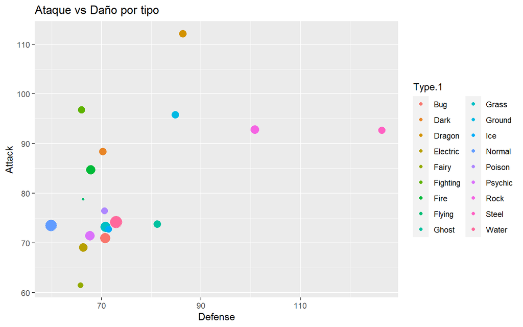

## Forcats, Stringr y Purr

Por último, tenemos estas tres librerías. No vamos a entrar mucho en detalle en ellas ya que son para tareas más específicas.

En particular, `forcats` nos permite manipular variables de tipo factor, `stringr` aquellas de tipo string y `purr` herramientas de programación funcional.

# TidyModels

[figure not shown]

Como vemos en clases, TidyModels se creó para unificar las librerías de Machine Learning en R, las cuales eran dispersas y poco compatibles. Además, buscó integrar los principios que rigen al TidyVerse que vimos anteriormente.

Durante el semestre profundizaremos en el funcionamiento de este paquete, aplicando los múltiples modelos que estudiaremos teóricamente.